# Layout对象初始化：

Layout对象代表了一块PCB Or Package设计，如果一个Project下有多个Design,可用多个Layout对象描述。

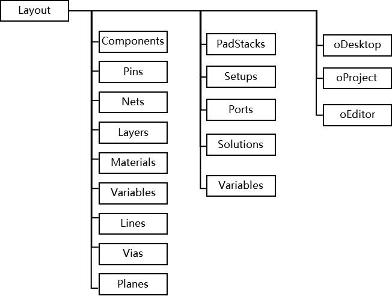

```
from pyLayout import Layout
layout = Layout("2022.2")
layout.initDesign()
```

> 1. layout = Layout()不指定版本是，pyLayout会尝试启动最新版本的AEDT界面。
> 2. 如果对应版本的AEDT是打开状态，默认使用当前AEDT窗口，不会打开新的AEDT界面。
> 3. 通过AEDT调用时(Tools->Run Script), 会默认继承当前窗口的版本号，指定的版本号不起作用。
> 4. layout.initDesign() 用于初始化Layout对象，初始化之后Layout对象的属性才有效。 Layout打开工程文件

在python环境执行时，需要按照pyAedt. (本测试环境为python环境)

```python
from pyLayout import Layout
layout = Layout("2022.2")
#layout.openAedt(r"C:\work\Project\AE\Script\test_pcb\galileo.aedt")
layout.initDesign()
```

# Layout对象的访问（Components）

Layout由Component, Layer, Material, Net, Pin, Line, Via, Plane, Setup, Solution, Variable等元素组成，这些元素可以通过Layout的集合对象来访问。比如Layout.Components对象代表了Layout所有Component的集合，可以用于获取所有的Component对象。  
Component, Layer, Material, Net, Pin, Line, Via, Plane, Setup, Solution, Variable的集合都支持类似调用方式。 以上对象的访问不区分大小写。

## 方法1：使用位号索引，访问Layout上的U1器件对象

```python
layout.Components["U1"]
```

## 方法2：直接作为属性，访问Layout上的U1器件对象

```python
layout.Components.U1
```

## 方法3: 直接访问Layout的U1对象，

Layout会尝试U1的类型，返回Compoent对象或者其它对象，如果遍历未发下U1元素，则抛出异常。（存在重名问题,不推荐）

```python
layout["U1"]
layout.U1
```

## 除了以上方法，可以直接使用index对器件进行访问：

```python
layout.Components[0]
layout.Components[0:5]
```

## 使用for循环迭代对象

```python
for comp in layout.Components:
    print(comp.Name)
```

## 访问Component的属性

```python
U1 = layout.Components["U1"]
dir(U1)
```

## 访问Component的pins

```python
for pin in U1.pins:
    print(pin.name,pin.net)
```

# Layout.Layers 对象访问

## 获取具体某层的layer对象

layer对象可以通过层名索引，或者通过位置获取。

```python
layout.layers["Top"] #使用名字获取
layout.layers["C1"] #获取第一个金属层，即Top层
layout.layers["CB1"] #反向获取第一个金属层，即BOTTOM层
layout.layers["D1"] #获取第一个介质层
layout.layers["DB1"] #反向第一个介质层
layout.layers["S1"] #获取叠层所有层的第一层
layout.layers["SB1"] #反向获取叠层所有层的第一层

layout.layers.Top #使用名字获取
layout.layers.C1 #使用名字获取
layout.layers.S1 #使用名字获取
```

## 获取和设置Layer的属性

```python
layout.layers["Top"]["Thickness"] #获取层厚度
layout.layers["Top"].Thickness #获取层厚度

layout.layers["Top"].Thickness = "1.9mil" #设置层厚度

layout.layers["Top"].Thickness = "1.9mil" #设置层厚度

layout.layers["Top"].Material
layout.layers["Top"].FillMaterial
layout.layers["Top"].Height
layout.layers["Top"].Lower
```

## 获取和设定粗糙度

```python
layout.layers["Top"].Roughness = "0.5um"
```

```python
layout.layers["Top"].UseRoughness = True
layout.layers["Top"].Roughness = "0.5um"
layout.layers["Top"].Roughness
```

# Variable 变量的增加和赋值

```python
layout.Variables.add("test1") #局部变量
layout.Variables.add("$test2") #全局变量

layout.Variables.test1 = "10mil"
layout.Variables["$test2"] = "20mil"

print(layout.Variables["test1"])
```

```python
varss = layout.Variables
print(varss.All)
```

# 访问和管理line,via,plane,pin,net的属性

可以通道名字直接索引对象，在3D Layout UI中看到的物体属性，均可直接访问，不区分大小写。

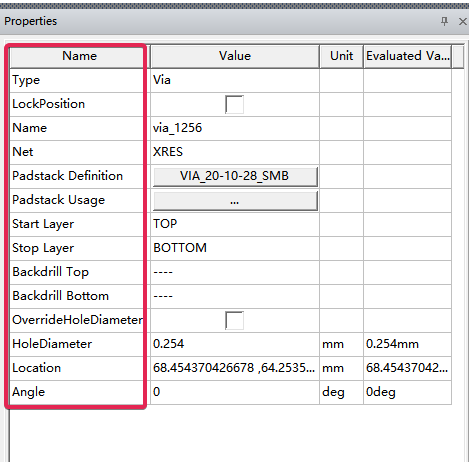

```python
via1 = layout.vias["via_1256"] #获取via对象
via2 = layout.vias.via_1256  #和via1为同一对象
print(via1 is via2)
```

## 对象属性的访问

可以通过key值访问，也可以作为属性访问，如果属性值有空格，允许去掉空格进行索引。不区分大小写。

```python
print(via1.name,via2.Net)
print(via1["Start Layer"]) #直接访问属性
print(via1["StartLayer"]) #属性可以去掉空格
print(via1.StartLayer) #和前面两种方法等同
```

## line,via,plane,pin,net 等UI可见属性同Via案例

```python
line1 = layout.lines["line_4200"]
pin1 = layout.pins["J2L1-48"]
pin1_1 = layout.pins.J2L1_48  # 属性中的-可以转换为_
p1 = layout.planes["poly_354"]
net1 = layout.nets["M_CAS_N"]
```

# setup的管理

setup 添加，获取，删除setup

```python
layout.setups.add("hfss1",solutionType = "HFSS")
layout.setups.add("siwave1",solutionType = "SIwave")
```

## hfss setup属性访问和设定

```python
# dir(layout.setups["hfss1"])

layout.setups["hfss1"].AdaptiveFrequency = "10Ghz"
layout.setups["hfss1"].DeltaS = "0.01"
layout.setups["hfss1"].MaxPasses = 20

print(layout.setups["hfss1"].AdaptiveFrequency)
print(layout.setups["hfss1"].DeltaS)
print(layout.setups["hfss1"].Order)
print(layout.setups["hfss1"].MaxPasses)
```

sweep的添加和删除

```python
#添加HFSS Sweep
layout.setups["hfss1"].addSweep("swp1")
layout.setups["hfss1"].Sweeps["swp1"].SweepData = "LIN 0GHz 20GHz 0.01GHz"
layout.setups["hfss1"].Sweeps["swp1"].UseQ3D = True
layout.setups["hfss1"].Sweeps["swp1"].InterpolatingTolerance = 0.001 #0.1%
layout.setups["hfss1"].Sweeps["swp1"].SweepType = "interpolating" #default


#添加SIwave Sweep
layout.setups["siwave1"].addSweep("swp1")
layout.setups["siwave1"].Sweeps["swp1"].SweepData = "LIN 0GHz 20GHz 0.01GHz"
layout.setups["siwave1"].Sweeps["swp1"].UseQ3D = True
layout.setups["siwave1"].Sweeps["swp1"].InterpolatingTolerance = 0.001 #0.1%
layout.setups["siwave1"].Sweeps["swp1"].SweepType = "interpolating" #default
```

# PadStack的访问

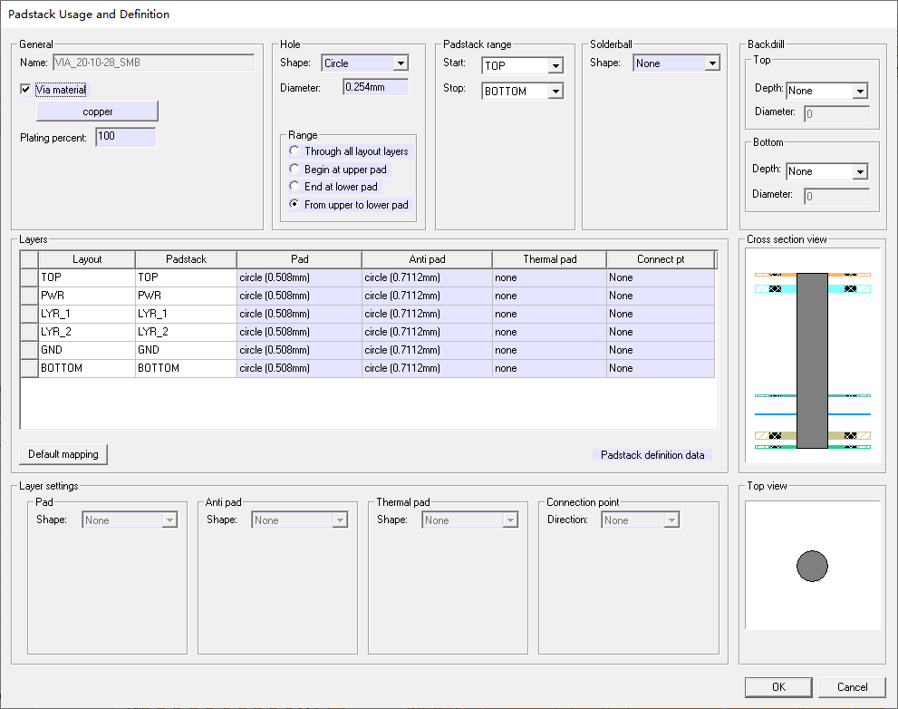

```python
padStk1_name = layout.Vias.via_2105["Padstack Definition"]
padStk1 = layout.PadStacks[padStk1_name]
print(padStk1.DrillSize)
print(padStk1["Top"].PadSize)
print(padStk1["Top"].AntipadPadSize)
print(padStk1["Top"].ThermalPadSize)

# layerName Top可以使用C1进行索引，即Concudtor的第一层
print(padStk1["C1"].PadSize)
print(padStk1["C1"].AntipadPadSize)
print(padStk1["C1"].ThermalPadSize)
```

## 按照属性直接访问

```python
print(padStk1["Top"].pad.shp)
print(padStk1["Top"].pad.Szs)

print(padStk1["Top"].ant.shp)
print(padStk1["Top"].ant.Szs)

print(padStk1["Top"].thm.shp)
print(padStk1["Top"].thm.Szs)
```

# Material属性访问

可以按照材料的属性名作为key值进行索引

[figure not shown]

```python
mat1 = layout.Materials["copper"]
dir(mat1)
```

```python
print(mat1["permittivity"])
print(mat1.DK) #同 permittivity

print(mat1["dielectric_loss_tangent"])
print(mat1.DF) #同 dielectric_loss_tangent

print(mat1["conductivity"])
print(mat1.Cond) #同 conductivity

print(mat1["Resistivity"]) # 1/conductivity
print(mat1.Resistivity) # 1/conductivity

print(mat1["permeability"])
print(mat1.ur) #同 permeability
```